# Butt et al: scRNAseq analysis of Camk2a-neurons

Agnes A. Steixner-Kumar

17 02 2020

```r
library(Seurat)
library(ComplexHeatmap)
```

```r
library(dplyr)
```

```r
library(circlize)
```

```r
library(scales)
library(VennDiagram)
```

# 1 Load and subset data

First, we load the scRNAseq data generated in Butt et al (2020) available on GEO (GSE162079). Next, we select only the population of interest, i.e. glutamateric cells.

```r
odd<-readRDS("GSE162079_Butt_et_al_hypoxia_Seurat.RDS") #load Seurat object
cam<-subset(odd, idents = c(grep("Glut", levels(odd), value = T),"Mossy_cells"))#select glutamatergic neurons = Camk2a+ neurons
```

# 2 Rename clusters

```r
cam<-RenameIdents(cam, "Glutamatergic2"="CA3", "Glutamatergic1"="CA1", "Glutamatergic0"="DG", "Glutamatergic3"="Glut3", "Glutamatergic4"="Glut4", "Mossy_cells"="Mossy") #rename identities
cam$final_identity<-Idents(cam) # set identities with new names
levels(cam)<-c("CA1", "CA3", "DG", "Glut3", "Glut4", "Mossy") # order levels
```

# 3 Shift embeddings

This is not important for the actual analysis and can be skipped. It was just done for more “compact” visualization on the UMAP: Cells very far down on UMAP_2 were shifted upwards

```r
emb<-Embeddings(cam, reduction = "umap")
#shift selected cells upwards on UMAP2
emb[,2][emb[,2]<(-15)]<-emb[,2][emb[,2]<(-15)]+12
#feed changed embeddings back into object
cam@reductions$umap@cell.embeddings<-emb
```

# 4 Visualize hippocampal region markers (not shown in publication)

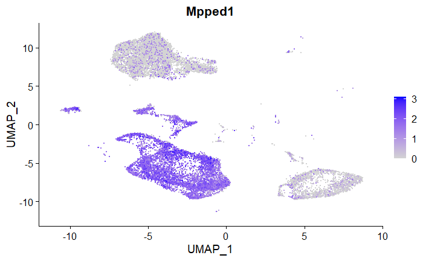

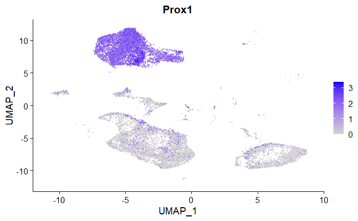

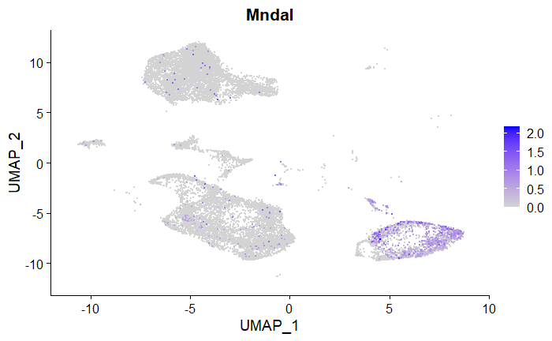

```r
FeaturePlot(cam, c("Mpped1", "Prox1", "Mndal"), reduction = "umap", order = T, combine = F) # Mpped1:CA1, Prox1: DG, Mndal: CA3
```

# 5 Figure 6a

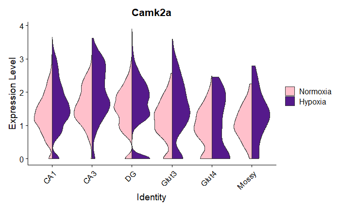

# 6 Camk2a regional expression

Here, Camk2a expression under normoxic levels was compared between regions to understand if differences in tdTomato labelling might be driven by differences in baseline Camk2a-levels.

```r
cam_nor<-subset(cam, group=="Normoxia") #subset only normoxic group

FindMarkers(cam_nor, ident.1 = "CA1", ident.2 = "CA3", features = "Camk2a", logfc.threshold = 0.1)
```

```
  |                                                  | 0 % ~calculating
  |++++++++++++++++++++++++++++++++++++++++++++++++++| 100% elapsed=00s
```

|  | p_val | avg_logFC | pct.1 | pct.2 | p_val_adj |
| --- | --- | --- | --- | --- | --- |
| Camk2a | 1.623943e-49 | -0.2527635 | 0.967 | 0.991 | 3.081595e-45 |

```r
FindMarkers(cam_nor, ident.1 = "CA1", ident.2 = "DG", features = "Camk2a", logfc.threshold = 0.1)
```

```
  |                                                  | 0 % ~calculating
  |++++++++++++++++++++++++++++++++++++++++++++++++++| 100% elapsed=00s
```

|  | p_val | avg_logFC | pct.1 | pct.2 | p_val_adj |
| --- | --- | --- | --- | --- | --- |
| Camk2a | 2.118432e-31 | -0.1602639 | 0.967 | 0.927 | 4.019936e-27 |

```r
FindMarkers(cam_nor, ident.1 = "CA3", ident.2 = "DG", features = "Camk2a", logfc.threshold = 0.1)
```

```
Error in FindMarkers.default(object = data.use, slot = data.slot, counts = counts,  :
  No features pass logfc.threshold threshold
```

# 7 Camk2a hypoxia-differential expression per region

Find out if upregulation of Camk2a under hypoxia is similar across hippocampal regions or if it follows a pattern that could explain tdTomato labelling differences.

```r
lapply(levels(cam), function(x) FindMarkers(cam, subset.ident = x, ident.1 = "Hypoxia", group.by = "group", logfc.threshold = 0.1, features = "Camk2a"))
```

[output not shown]

|  | p_val | avg_logFC | pct.1 | pct.2 | p_val_adj |
| --- | --- | --- | --- | --- | --- |
| Camk2a | 3.834774e-52 | 0.3822062 | 0.925 | 0.967 | 7.276868e-48 |

|  | p_val | avg_logFC | pct.1 | pct.2 | p_val_adj |
| --- | --- | --- | --- | --- | --- |
| Camk2a | 3.797443e-34 | 0.5153126 | 0.962 | 0.991 | 7.206028e-30 |

|  | p_val | avg_logFC | pct.1 | pct.2 | p_val_adj |
| --- | --- | --- | --- | --- | --- |
| Camk2a | 1.313018e-17 | 0.1886453 | 0.833 | 0.927 | 2.491582e-13 |

|  | p_val | avg_logFC | pct.1 | pct.2 | p_val_adj |
| --- | --- | --- | --- | --- | --- |
| Camk2a | 4.460105e-09 | 0.5072933 | 0.826 | 0.889 | 8.463495e-05 |

|  | p_val | avg_logFC | pct.1 | pct.2 | p_val_adj |
| --- | --- | --- | --- | --- | --- |
| Camk2a | 0.6473475 | 0.238861 | 0.631 | 0.809 | 1 |

|  | p_val | avg_logFC | pct.1 | pct.2 | p_val_adj |
| --- | --- | --- | --- | --- | --- |
| Camk2a | 0.1217199 | 0.3236829 | 0.861 | 0.97 | 1 |

```
NA
```

# 8 General differential expression under hypoxia

Find genes that are regulated under hypoxia.

```r
DE<-FindMarkers(cam, group.by = "group", ident.1 = "Hypoxia", logfc.threshold = 0.25) # calculate DE
```

# 9 Figure 6b

Create heatmap of top hypoxia regulated genes.

```r
set.seed(123) # seed for reproducibility
# create heatmap and save
h<-Heatmap(mat_goi
          , name = 'Expression',  col = c('white', 'blue2', 'black'), column_order = orderedCells, show_column_names = F, row_km = 5, row_km_repeats = 5,column_km = 3, column_km_repeats = 5, top_annotation = col_anno,  heatmap_width = unit(6, "cm"), heatmap_height = unit(15, "cm"),heatmap_legend_param = list(direction = "horizontal"),row_names_gp = gpar(fontsize = 10))
```

[output not shown]

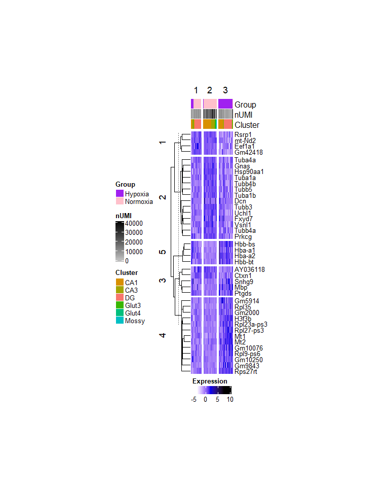

```r
 draw(h, annotation_legend_side='left', heatmap_legend_side = "bottom")
```

# 10 Hypoxia-differential expression by cluster

```r
DE_per_cluster<-lapply(levels(cam), function(x) FindMarkers(cam, subset.ident = x,ident.1 = "Hypoxia", group.by = "group", logfc.threshold = 0.25, max.cells.per.ident = 2296, random.seed = 123)) # calculate hypoxia DE per cluster on fixed cluster size, i.e. cluster size set equal to CA3 cluster size
names(DE_per_cluster)<-levels(cam) # name list

DE_per_cluster<-lapply(DE_per_cluster, function(x) x[x$p_val_adj<0.05,]) # select only DE that survive multiple testing correction
DE_per_cluster<-DE_per_cluster[1:3] # keep only the DE of the large regional clusters
```